# HBV Genotype A mutations

2022-11-4

## Data Clean up

### Import data

Sequences of HBV genotype A downloaded from Hepatitis B database (https://hbvdb.lyon.inserm.fr/HBVdb/). All 982 sequences were aligned with a reference sequence using BioAider. The total mutation count at different nucleotides was reported in excel file. Import with

```r
A_mut <- read_xlsx("genotype_A_muts.xlsx")
```

Take a glimpse into the data this data has 3 variables and 4261 observations

```r
glimpse(A_mut)
```

```
## Rows: 4,261
## Columns: 3
## $ `Reference sequence: gnl|hbvnuc|Sample Lab Genotype A|982 Sequences.` <chr> …
## $ ...2                                                                  <chr> …
## $ ...3                                                                  <chr> …
```

Processing of the data - renaming the variables and change characters to numbers

```r
A_mut <- clean_names(A_mut)
A_mut <- rename(A_mut, position = reference_sequence_gnl_hbvnuc_sample_lab_genotype_a_982_sequences)
A_mut <- rename(A_mut, mutation = x2)
A_mut <- rename(A_mut, count = x3)

A_mut %>%
  filter(!row_number() %in% c(1, 2))

A_mut <- A_mut %>%
  mutate(position = parse_number(position)) %>%
  mutate(count = parse_number(count))
```

```r
A_mut <- A_mut %>%
  filter(!row_number() %in% c(1, 2))
```

### Mutations in the Polymerase

```r
poly <- A_mut %>%
  filter(position <= 1377 | position>= 2307)

poly <- arrange(poly, position)
poly <-mutate(poly, index = position -2306)
poly<- mutate(poly, index_n = if_else(index<0, index+3221, index))
poly<- arrange(poly, index_n)
poly<- poly %>%
  mutate(region = case_when(
    index_n < 550 ~ "terminal_protein",
    index_n < 1041 ~ "spacer",
    index_n < 2077 ~ "reverse_transcriptase",
    TRUE ~ "rnase_h"))
poly_200 <- poly %>%
  filter(!count < 200)
```

## Plotting the Number of Mutations

[figure not shown]

```r
poly_200 %>%
  ggplot(aes(x = index_n, y = count)) +
  geom_jitter(aes(color = region))+
  theme_grey()+
  paletteer::scale_color_paletteer_d("RColorBrewer::RdBu",
                                     labels = c("Terminal Protein",
                                                "Spacer",
                                                "Reverse Transcriptase",
                                                "RNase H"))+
  labs( x = "Nucleotide Position", y = "Count",
        title = "Number of Mutations in HBV Polymerase",
        color = "Domains")+
  annotate("text",x=480, y = 940, label = c("nt436"), size = 3) +
  annotate("point",x=c(436, 856,1915,1920,1919,2159,2193,2273),
           y = c(978,971,979,970,979,979,979,980), color = 'blue',size = 3,
           alpha =0.3) +
  annotate("text",x=850, y = 1010, label = c("nt856"), size = 3) +
  annotate("text",x=1800, y = 1030, label = c("nt1915, nt1920, nt1929"),size = 3) +
  annotate("text",x=1985, y = 940, label = c("nt2159,nt2173,nt2193"),size = 3)
```

Number of mutation sites in each region

```r
domain_mut <- poly %>%
  group_by(region) %>%
  summarise(total = sum(count), site = n_distinct(position)) %>%
  mutate(percentage = total/site)
glimpse(domain_mut)
```

```
## Rows: 4
## Columns: 4
## $ region     <chr> "reverse_transcriptase", "rnase_h", "spacer", "terminal_pro…
## $ total      <dbl> 33412, 8824, 23062, 27773
## $ site       <int> 632, 123, 422, 366
## $ percentage <dbl> 52.86709, 71.73984, 54.64929, 75.88251
```

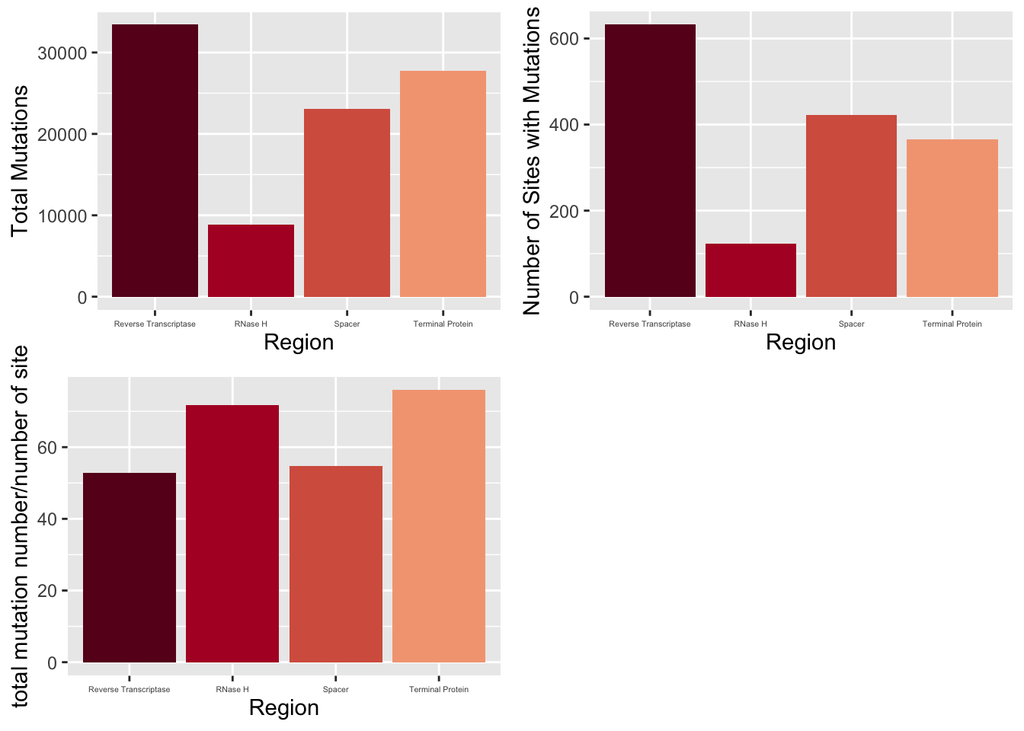

```r
plot1 <- domain_mut %>%
  ggplot(aes(x = region, y = total))+
  geom_col(aes(fill = region))+
  scale_fill_paletteer_d("RColorBrewer::RdBu")+
  labs(x = 'Region', y = 'Total Mutations')+
  theme(axis.text.x = element_text(size = 4),
        legend.position = "none") +
  scale_x_discrete(labels = c("Reverse Transcriptase","RNase H",
                              "Spacer","Terminal Protein"))

plot2 <- domain_mut %>%
  ggplot(aes(x = region, y = site))+
  geom_col(aes(fill = region))+
  scale_fill_paletteer_d("RColorBrewer::RdBu")+
  labs(x = 'Region', y = 'Number of Sites with Mutations')+
  theme(axis.text.x = element_text(size = 4),
        legend.position = "none") +
  scale_x_discrete(labels = c("Reverse Transcriptase","RNase H",
                              "Spacer","Terminal Protein"))

plot3 <- domain_mut %>%
  ggplot(aes(x = region, y = percentage))+
  geom_col(aes(fill = region))+
  scale_fill_paletteer_d("RColorBrewer::RdBu")+
  labs(x = 'Region', y = "total mutation number/number of site")+
  theme(axis.text.x = element_text(size = 4),
        legend.position = "none") +
  scale_x_discrete(labels = c("Reverse Transcriptase","RNase H",
                              "Spacer","Terminal Protein"))

plot_grid(plot1, plot2, plot3)
```

## Future Direction

1. Looking at the top mutation hotspots and their association with each other and try to identify if there’s correlation between mutations and phenotypes
2. Identify the amino acid changes corresponding to the nucleotide changes